# Self-rated overall quality of life in Brazilian medical students

Dataset 8: Resilience, learning environment and quality of life in Brazilian medical students

RSR feasibility analysis

2026-08-03

# Introduction

Tempski and colleagues surveyed a random sample of 1,350 students at 22 Brazilian medical schools in 2011-2012, measuring quality of life (WHOQOL-BREF), the perceived educational environment (DREEM), resilience, depressive symptoms and anxiety in a single cross-sectional questionnaire (Tempski et al., *PLOS ONE* 2015; doi:10.1371/journal.pone.0131535). Alongside the multi-item instruments, students rated their *overall* quality of life - life as a whole, not just medical school - on a single 1-10 item. This global self-rating is the outcome that matters most to students themselves, and asking how much of it is explained by anything a medical school controls is a fair test of how far training shapes a student’s life.

**Aim.** Among Brazilian medical students, we examined which of sex, age, stage of the course, school legal status, resilience, the perceived educational environment and trait anxiety are independently associated with self-rated overall quality of life, mutually adjusting for the others.

This is a *Purpose 3* analysis: several predictors are of interest and the question is which remain associated with the outcome after mutual adjustment.

# Methods

**Data source.** Multicentre cross-sectional survey of a random sample of 1,350 students drawn from 22 medical schools across Brazil, stratified by stage of the course (basic sciences, clinical sciences, clerkship). All variables used here are complete.

**Variables.** The outcome is `overall_qol`, the student’s self-rating of overall quality of life on a 1-10 scale (observed range 2 to 10, higher is better). Predictors are sex (reference: female, the larger group), age in years, stage of the course (reference: basic sciences, the earliest stage), school legal status (reference: public, the larger group and the traditional Brazilian medical school), the resilience scale score (16-98, higher = more resilient), the DREEM global score (sum of the five DREEM subscales, higher = a more positive perceived educational environment) and the trait anxiety scale (20-80, higher = more anxious). Continuous predictors are modelled per one-unit increase.

Deliberate choices about construct overlap. `dreem_global` is used **instead of** its five subscales, which sum to it exactly. Only one of the three negative-affect scales is included: `trait_anxiety` correlates 0.73 with `bdi_depression` and 0.70 with `state_anxiety`, so entering all three would split one construct across three collinear terms; trait anxiety was chosen as the dispositional measure, least likely to be a same-day consequence of how life is going. The four WHOQOL domains are excluded as predictors because they are alternative quality-of-life measurements rather than explanations of quality of life - `whoqol_psychological` correlates 0.45 with this outcome and would simply restate it.

**Statistical analysis.** Linear regression (`lm()`), justified because the outcome is an ordered 1-10 rating conventionally treated as continuous. We fitted a univariable model for each predictor first, then a single multivariable model containing all of them. Predictors were chosen in advance on subject-matter grounds, not by significance. Significance threshold 0.05; estimates are reported with 95% confidence intervals. Assumptions were checked with `performance::check_model()`. Analysis used R version 4.6.0 (2026-04-24) with tidyverse, gtsummary and performance.

**Missing data.** Complete-case analysis: 1350 of 1350 rows were analysed (0 dropped).

# Results

## Sample characteristics

**Table 1. Sample characteristics.**

| **Characteristic** | **N** | **N = 1,350**<sup>1</sup> |
| --- | --- | --- |
| Overall quality of life (1-10) | 1,350 |  |
| 2 |  | 2 (0.1%) |
| 3 |  | 9 (0.7%) |
| 4 |  | 8 (0.6%) |
| 5 |  | 44 (3.3%) |
| 6 |  | 93 (6.9%) |
| 7 |  | 305 (23%) |
| 8 |  | 452 (33%) |
| 9 |  | 345 (26%) |
| 10 |  | 92 (6.8%) |
| Sex | 1,350 |  |
| Female |  | 714 (53%) |
| Male |  | 636 (47%) |
| Age (years) | 1,350 | 22.00 (21.00, 24.00) |
| Stage of course | 1,350 |  |
| Basic sciences |  | 459 (34%) |
| Clinical sciences |  | 491 (36%) |
| Clerkship |  | 400 (30%) |
| School legal status | 1,350 |  |
| Public |  | 882 (65%) |
| Private |  | 468 (35%) |
| Resilience score (16-98) | 1,350 | 81 (73, 88) |
| DREEM global score (0-200) | 1,350 | 120 (101, 139) |
| Trait anxiety (20-80) | 1,350 | 45 (37, 53) |

<sup>1</sup> n (%); Median (Q1, Q3)

The median overall quality-of-life rating was 8 out of 10 (IQR 7 to 9), a point higher than the same students’ rating of their medical-school quality of life. The distribution is compressed against the top of the scale: 66% of students chose 8, 9 or 10, and only 19 students in 1350 chose 4 or less. This ceiling effect (skewness -0.84) limits how much variance any model can explain and recurs throughout the diagnostics.

## Exploratory figure

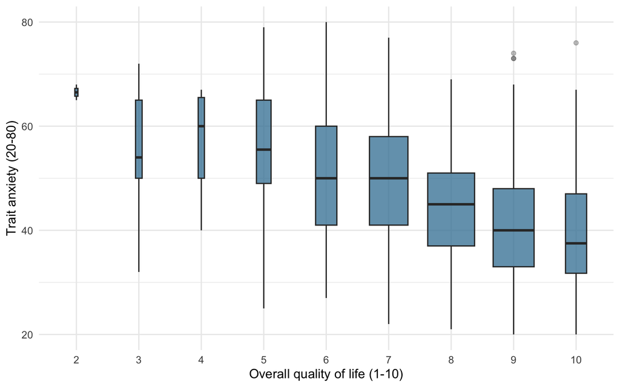

Figure 1. Distribution of trait anxiety by overall quality-of-life rating. Boxes show the median and interquartile range; the width of each box is proportional to the square root of the number of students giving that rating.

Trait anxiety falls steadily as the overall quality-of-life rating rises, but the box widths show how unbalanced the outcome is: the great majority of students sit at 7, 8 or 9, and the ratings at the bottom of the scale rest on a handful of students each.

## Univariable models

**Univariable linear regression.**

| **Characteristic** | **Beta** | **95% CI** | **p-value** |
| --- | --- | --- | --- |
| Sex |  |  |  |
| Female | — | — |  |
| Male | 0.12 | -0.02, 0.25 | 0.093 |
| Age (years) | -0.05 | -0.07, -0.02 | <0.001 |
| Stage of course |  |  |  |
| Basic sciences | — | — |  |
| Clinical sciences | 0.03 | -0.13, 0.19 | 0.7 |
| Clerkship | -0.08 | -0.25, 0.10 | 0.4 |
| School legal status |  |  |  |
| Public | — | — |  |
| Private | 0.15 | 0.01, 0.29 | 0.041 |
| Resilience score (16-98) | 0.03 | 0.02, 0.03 | <0.001 |
| DREEM global score (0-200) | 0.01 | 0.01, 0.02 | <0.001 |
| Trait anxiety (20-80) | -0.04 | -0.05, -0.03 | <0.001 |

Abbreviation: CI = Confidence Interval

Trait anxiety is the strongest crude predictor: each additional point is associated with a 0.040-point *lower* overall quality-of-life rating (95% CI -0.045 to -0.034, p < 0.001), which across the observed 20-to-80 range is about 2.4 points of the 1-10 scale. Resilience is positively associated (0.029 per point, 95% CI 0.024 to 0.034), as is the DREEM global score (0.013 per point). Each additional year of age goes with a 0.046-point lower rating (p < 0.001), and private-school students rate their overall quality of life 0.149 points higher than public-school students (p = 0.041). Sex (p = 0.09) and stage of the course (clerkship p = 0.38) show no crude association.

## Why adjustment is needed

Several crude estimates here are clearly contaminated by other variables in the file. **Trait anxiety** confounds the resilience association: dispositionally anxious students score much lower on the resilience scale (*r* = -0.61) and rate their lives worse, so a large part of the crude resilience coefficient is really anxiety. **Trait anxiety** does the same to the DREEM association, since anxious students rate their educational environment more harshly (*r* = -0.43); without adjustment, “a better learning environment goes with a better life” is partly just “less anxious students say better things about everything”. **Stage of the course** confounds the crude age association, and severely: clerkship students are on average four years older than basic-sciences students, so the crude age coefficient mixes ageing with progression through the course, and the two must be separated. **The DREEM global score** confounds the school legal status contrast: private-school students rate their educational environment about 13 points higher on average (mean 128 versus 115), so their apparent overall quality-of-life advantage may be nothing more than that. Fitting all seven predictors together makes each estimate conditional on the rest.

## Multivariable model

**Multivariable linear regression.**

| **Characteristic** | **Beta** | **95% CI** | **p-value** |
| --- | --- | --- | --- |
| Sex |  |  |  |
| Female | — | — |  |
| Male | -0.03 | -0.16, 0.10 | 0.7 |
| Age (years) | -0.06 | -0.09, -0.04 | <0.001 |
| Stage of course |  |  |  |
| Basic sciences | — | — |  |
| Clinical sciences | 0.15 | -0.01, 0.30 | 0.066 |
| Clerkship | 0.20 | 0.02, 0.38 | 0.031 |
| School legal status |  |  |  |
| Public | — | — |  |
| Private | 0.05 | -0.09, 0.18 | 0.5 |
| Resilience score (16-98) | 0.01 | 0.00, 0.01 | 0.040 |
| DREEM global score (0-200) | 0.01 | 0.00, 0.01 | <0.001 |
| Trait anxiety (20-80) | -0.03 | -0.04, -0.02 | <0.001 |

Abbreviation: CI = Confidence Interval

**Model fit**

| Statistic | Value |
| --- | --- |
| R-squared | 0.171 |
| Adjusted R-squared | 0.166 |
| Residual SE | 1.16 |
| n | 1350 |
| Model df | 8 |

The model explains 17.1% of the variance in overall quality of life (adjusted R-squared 0.166) - the lowest of any outcome in this dataset, and a useful reminder that a single global life rating is driven mostly by things a medical-school survey does not measure. Holding the other six predictors fixed, each trait-anxiety point is associated with -0.030 (95% CI -0.038 to -0.023) points of the rating (about 1.8 points across the observed range), each DREEM point with 0.006 (95% CI 0.003 to 0.009) (about 0.12 points per 20 DREEM points) and each year of age with -0.063 (95% CI -0.088 to -0.039) points. Resilience retains a small but significant independent association (0.007 (95% CI 0.000 to 0.013) per point). Clerkship students rate their overall quality of life 0.201 (95% CI 0.018 to 0.384) points higher than basic-sciences students (clinical sciences 0.146 (95% CI -0.009 to 0.301)) once age and the rest are held fixed. Sex (-0.028 (95% CI -0.156 to 0.100)) and private schooling (0.047 (95% CI -0.088 to 0.182)) show no independent association. These are conditional associations in a cross-sectional survey, not effects.

## Unadjusted versus adjusted

**Table 2. Unadjusted and adjusted estimates.**

| **Characteristic** | **Unadjusted** **Beta** | **Unadjusted** **95% CI** | **Unadjusted** **p-value** | **Adjusted** **Beta** | **Adjusted** **95% CI** | **Adjusted** **p-value** |
| --- | --- | --- | --- | --- | --- | --- |
| Sex |  |  |  |  |  |  |
| Female | — | — |  | — | — |  |
| Male | 0.12 | -0.02, 0.25 | 0.093 | -0.03 | -0.16, 0.10 | 0.7 |
| Age (years) | -0.05 | -0.07, -0.02 | <0.001 | -0.06 | -0.09, -0.04 | <0.001 |
| Stage of course |  |  |  |  |  |  |
| Basic sciences | — | — |  | — | — |  |
| Clinical sciences | 0.03 | -0.13, 0.19 | 0.7 | 0.15 | -0.01, 0.30 | 0.066 |
| Clerkship | -0.08 | -0.25, 0.10 | 0.4 | 0.20 | 0.02, 0.38 | 0.031 |
| School legal status |  |  |  |  |  |  |
| Public | — | — |  | — | — |  |
| Private | 0.15 | 0.01, 0.29 | 0.041 | 0.05 | -0.09, 0.18 | 0.5 |
| Resilience score (16-98) | 0.03 | 0.02, 0.03 | <0.001 | 0.01 | 0.00, 0.01 | 0.040 |
| DREEM global score (0-200) | 0.01 | 0.01, 0.02 | <0.001 | 0.01 | 0.00, 0.01 | <0.001 |
| Trait anxiety (20-80) | -0.04 | -0.05, -0.03 | <0.001 | -0.03 | -0.04, -0.02 | <0.001 |

Abbreviation: CI = Confidence Interval

**Resilience** moves furthest toward the null, from 0.029 crude to 0.007 adjusted - only 24% of the crude coefficient survives, and it is barely significant (p = 0.040) where crudely it was overwhelming. Most of what the resilience scale contributed was trait anxiety. **The DREEM global score** loses about half (0.013 to 0.006, 43% retained), for the same reason. **Trait anxiety** shrinks least (-0.040 to -0.030, 76% retained) and is the dominant predictor either way.

## Diagnostics

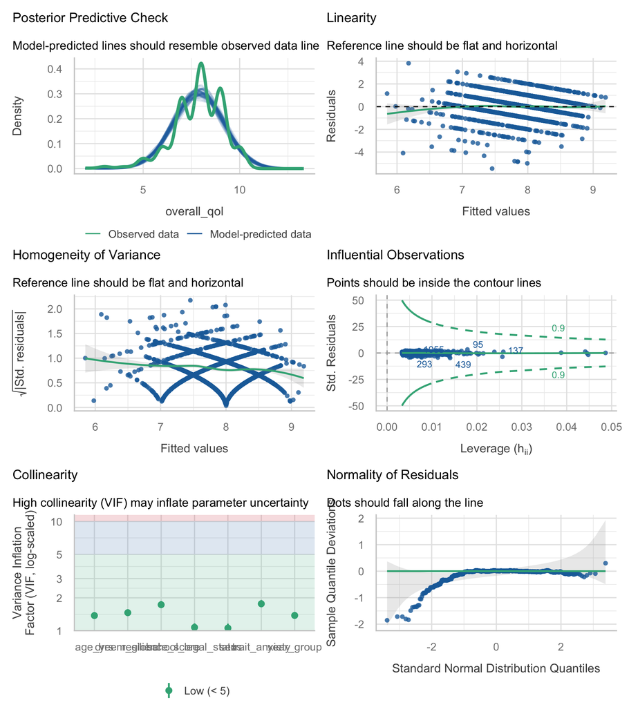

**Variance inflation factors**

| Term | VIF | Tolerance |
| --- | --- | --- |
| trait_anxiety | 1.76 | 0.567 |
| resilience_score | 1.73 | 0.578 |
| dreem_global | 1.46 | 0.684 |
| age_yrs | 1.38 | 0.727 |
| year_group | 1.38 | 0.725 |
| school_legal_status | 1.07 | 0.932 |
| sex | 1.06 | 0.946 |

**HC3 robust standard errors (sensitivity check)**

| term | estimate | robust SE | statistic | p.value |
| --- | --- | --- | --- | --- |
| (Intercept) | 9.343 | 0.523 | 17.87 | <0.001 |
| sexMale | -0.028 | 0.067 | -0.42 | 0.6758 |
| age_yrs | -0.063 | 0.014 | -4.41 | <0.001 |
| year_groupClinical sciences | 0.146 | 0.081 | 1.81 | 0.0705 |
| year_groupClerkship | 0.201 | 0.101 | 2.00 | 0.0461 |
| school_legal_statusPrivate | 0.047 | 0.072 | 0.66 | 0.5101 |
| resilience_score | 0.007 | 0.004 | 1.91 | 0.0559 |
| dreem_global | 0.006 | 0.001 | 3.89 | <0.001 |
| trait_anxiety | -0.030 | 0.004 | -7.51 | <0.001 |

The robust standard errors are close to the model-based ones, but one conclusion does change: **resilience** moves from p = 0.040 under model-based standard errors to p = 0.056 under HC3, crossing the 0.05 threshold. It was borderline to begin with and should be described as such rather than as an established association. Trait anxiety, the DREEM score, age and the clerkship contrast all keep their significance status.

**Influential points.** No observation exceeds the Cook’s distance threshold; the largest is 0.037. The few students who rated their life 2 or 3 are the highest-leverage points but none is individually decisive.

**Collinearity.** The highest VIF is 1.76 (trait_anxiety), with trait anxiety at 1.76 and resilience at 1.73. All values are below 2 and far from the threshold of 5, so the model is stable. This is the payoff for excluding `bdi_depression` and `state_anxiety`: had all three negative-affect scales been entered, their mutual correlations of 0.59 to 0.73 would have inflated the standard errors substantially and made the split between them arbitrary.

# Discussion

Self-rated overall quality of life in Brazilian medical students is associated most strongly with trait anxiety, and only weakly with anything the medical school controls. A 20-point better perceived educational environment corresponds to roughly 0.12 of a point on the 1-10 scale - real but small next to the roughly 0.6 points associated with a 20-point difference in trait anxiety. The model explains 17% of the variance, the least of any outcome in this dataset, which is the honest headline: how a student rates their life as a whole depends chiefly on family, relationships, money and temperament, of which this survey measured only temperament. Compared with `medical_school_qol` - the same students’ rating of their medical-school quality of life - the DREEM association here is roughly half as strong, exactly as one would expect if the learning environment affects the school-specific part of life more than life in general.

**Limitations.** *Ceiling effect and a single-item outcome.* Overall quality of life is one 1-10 question with no reliability estimate; 66% of students answered 8 or more, so the outcome has little room to vary upward, measurement error attenuates every coefficient toward the null, and R-squared is capped low for reasons that have nothing to do with the predictors. *Clustering is not modelled.* Students came from 22 medical schools, but the released file carries no school identifier - only `school_legal_status` and `school_location` - so students within a school cannot be treated as correlated; the standard errors are too narrow, particularly for the school-level contrast, and no random intercept can be fitted. *Cross-sectional design.* Trait anxiety and quality of life were measured on the same day, and a student having a bad year will report both a low life rating and high anxiety; the direction of the association cannot be established. *Common-method bias.* Every psychosocial variable is self-reported on one form, which inflates all associations at once. *Unmeasured confounders* - family income, relationship status, living arrangements, physical illness - are absent from the file and are precisely the determinants of a global life rating.

**Future work.** Add a small number of socio-demographic items (income, relationship status, living arrangements) and repeat the rating at two time points, retaining school identifiers so that between-school variation can be separated out.

# Feasibility notes

*Not part of a student report.*

- **Knits cleanly, statistically stable.** n = 1,350 complete cases, seven predictors, max VIF 1.76, max Cook’s distance 0.037, no sparse cells among the predictors.
- **Lowest R-squared of the six outcomes** (0.171, adjusted 0.166). Nothing is broken; the outcome is simply a one-item global life rating that this survey is not equipped to explain. Students should be warned in advance so they do not read a low R-squared as their own failure - but a student who wants an impressive-looking model will be disappointed.
- **Worst outcome distribution of the six after `bdi_depression`.** Nine observed values, 66% of students at 8-10, skewness -0.84, and only 19 students at 4 or below. Normality is firmly rejected, residuals are gridded, and heteroscedasticity is strong. This is the **only outcome of the six where HC3 changes a conclusion**: resilience goes from p = 0.040 to p = 0.056. The linear model is a convenience here, not a good fit; ordinal regression would be the honest alternative.
- **Least tautological of the six.** This is the only outcome whose strongest predictor (trait anxiety, *r* = -0.37) is not near-collinear with it. Compare `whoqol_psychological`, where trait anxiety correlates -0.75. The trade-off is the low R-squared - the two facts are the same fact.
- **Good suppression example.** Clerkship flips from null to significantly positive once age is held fixed, and age strengthens correspondingly; the age/stage relationship in this file (mean age 20.9, 22.8, 24.8 across the three stages) makes this easy to explain.
- **Guardrails.** `dreem_global` must never appear with its five subscales; no WHOQOL domain as a predictor; only one of BDI / state / trait anxiety.
- **Verdict: workable and safe, but underpowered in explanatory terms.** A good choice for a student who understands that a small R-squared can be the right answer; a poor choice for one who wants a strong result.